# Risk Factor Analysis

## Outcome Variable

**Outcome Variable:** stunted

## Predictor Variables

**Intervention Variable:** nhh

**Adjustment Set:**

- arm
- W_mage
- meducyrs
- feducyrs
- hhwealth_quart
- W_mhtcm
- W_mwtkg
- W_mbmi
- W_nrooms
- cleanck
- impfloor
- impsan
- safeh20
- delta_W_mage
- delta_meducyrs
- delta_feducyrs
- delta_hhwealth_quart
- delta_W_mhtcm
- delta_W_mwtkg
- delta_W_mbmi
- delta_W_nrooms
- delta_cleanck
- delta_impfloor
- delta_impsan
- delta_safeh20

## Stratifying Variables

The analysis was stratified on these variable(s):

- agecat
- studyid
- country

## Data Summary

| agecat | studyid | country | nhh | stunted | n_cell | n |
| --- | --- | --- | --- | --- | --- | --- |
| Birth | ki1000108-IRC | INDIA | 3 or less | 0 | 51 | 388 |
| Birth | ki1000108-IRC | INDIA | 3 or less | 1 | 3 | 388 |
| Birth | ki1000108-IRC | INDIA | 4-5 | 0 | 128 | 388 |
| Birth | ki1000108-IRC | INDIA | 4-5 | 1 | 22 | 388 |
| Birth | ki1000108-IRC | INDIA | 6-7 | 0 | 89 | 388 |
| Birth | ki1000108-IRC | INDIA | 6-7 | 1 | 14 | 388 |
| Birth | ki1000108-IRC | INDIA | 8+ | 0 | 75 | 388 |
| Birth | ki1000108-IRC | INDIA | 8+ | 1 | 6 | 388 |
| Birth | ki1017093-NIH-Birth | BANGLADESH | 3 or less | 0 | 7 | 28 |
| Birth | ki1017093-NIH-Birth | BANGLADESH | 3 or less | 1 | 0 | 28 |
| Birth | ki1017093-NIH-Birth | BANGLADESH | 4-5 | 0 | 10 | 28 |
| Birth | ki1017093-NIH-Birth | BANGLADESH | 4-5 | 1 | 1 | 28 |
| Birth | ki1017093-NIH-Birth | BANGLADESH | 6-7 | 0 | 7 | 28 |
| Birth | ki1017093-NIH-Birth | BANGLADESH | 6-7 | 1 | 0 | 28 |
| Birth | ki1017093-NIH-Birth | BANGLADESH | 8+ | 0 | 3 | 28 |
| Birth | ki1017093-NIH-Birth | BANGLADESH | 8+ | 1 | 0 | 28 |
| Birth | ki1017093c-NIH-Crypto | BANGLADESH | 3 or less | 0 | 7 | 27 |
| Birth | ki1017093c-NIH-Crypto | BANGLADESH | 3 or less | 1 | 1 | 27 |
| Birth | ki1017093c-NIH-Crypto | BANGLADESH | 4-5 | 0 | 7 | 27 |
| Birth | ki1017093c-NIH-Crypto | BANGLADESH | 4-5 | 1 | 2 | 27 |
| Birth | ki1017093c-NIH-Crypto | BANGLADESH | 6-7 | 0 | 5 | 27 |
| Birth | ki1017093c-NIH-Crypto | BANGLADESH | 6-7 | 1 | 2 | 27 |
| Birth | ki1017093c-NIH-Crypto | BANGLADESH | 8+ | 0 | 3 | 27 |
| Birth | ki1017093c-NIH-Crypto | BANGLADESH | 8+ | 1 | 0 | 27 |
| 6 months | ki1000108-IRC | INDIA | 3 or less | 0 | 44 | 407 |
| 6 months | ki1000108-IRC | INDIA | 3 or less | 1 | 14 | 407 |
| 6 months | ki1000108-IRC | INDIA | 4-5 | 0 | 116 | 407 |
| 6 months | ki1000108-IRC | INDIA | 4-5 | 1 | 42 | 407 |
| 6 months | ki1000108-IRC | INDIA | 6-7 | 0 | 81 | 407 |
| 6 months | ki1000108-IRC | INDIA | 6-7 | 1 | 25 | 407 |

[output cut: 82 more lines]

The following strata were considered:

- agecat: 24 months, studyid: ki1000108-IRC, country: INDIA
- agecat: 24 months, studyid: ki1017093-NIH-Birth, country: BANGLADESH
- agecat: 24 months, studyid: ki1017093b-PROVIDE, country: BANGLADESH
- agecat: 24 months, studyid: ki1017093c-NIH-Crypto, country: BANGLADESH
- agecat: 24 months, studyid: ki1148112-LCNI-5, country: MALAWI
- agecat: 6 months, studyid: ki1000108-IRC, country: INDIA
- agecat: 6 months, studyid: ki1000304b-SAS-FoodSuppl, country: INDIA
- agecat: 6 months, studyid: ki1017093-NIH-Birth, country: BANGLADESH
- agecat: 6 months, studyid: ki1017093b-PROVIDE, country: BANGLADESH
- agecat: 6 months, studyid: ki1017093c-NIH-Crypto, country: BANGLADESH
- agecat: 6 months, studyid: ki1148112-LCNI-5, country: MALAWI
- agecat: Birth, studyid: ki1000108-IRC, country: INDIA
- agecat: Birth, studyid: ki1017093-NIH-Birth, country: BANGLADESH
- agecat: Birth, studyid: ki1017093c-NIH-Crypto, country: BANGLADESH

### Dropped Strata

Some strata were dropped due to rare outcomes:

- agecat: Birth, studyid: ki1000108-IRC, country: INDIA
- agecat: Birth, studyid: ki1017093-NIH-Birth, country: BANGLADESH
- agecat: Birth, studyid: ki1017093c-NIH-Crypto, country: BANGLADESH

## Methods Detail

We’re interested in the causal parameters $E[Y_a]$ for all values of $a \in \mathcal{A}$. These parameters represent the mean outcome if, possibly contrary to fact, we intervened to set all units to have $A=a$. Under the randomization and positivity assumptions, these are identified by the statistical parameters $\psi_a=E_W[E_{Y|A,W}(Y|A=a,W)]$. In addition, we’re interested in the mean of $Y$, $E[Y]$ under no intervention (the observed mean). We will estimate these parameters by using SuperLearner to fit the relevant likelihood factors – $E_{Y|A,W}(Y|A=a,W)$ and $p(A=a|W)$, and then updating our likelihood fit using a joint TMLE.

For unadjusted analyses ($W=\{\}$), initial likelihoods were estimated using Lrnr_glm to estimate the simple $E(Y|A)$ and Lrnr_mean to estimate $p(A)$. For adjusted analyses, a small library containing Lrnr_glmnet, Lrnr_xgboost, and Lrnr_mean was used.

Having estimated these parameters, we will then use the delta method to estimate relative risks and attributable risks relative to a prespecified baseline level of $A$.

# Results Detail

## Results Plots

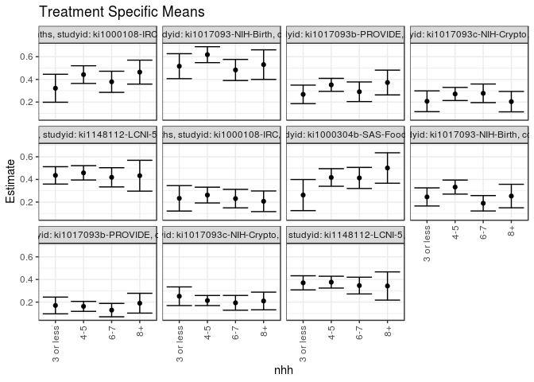

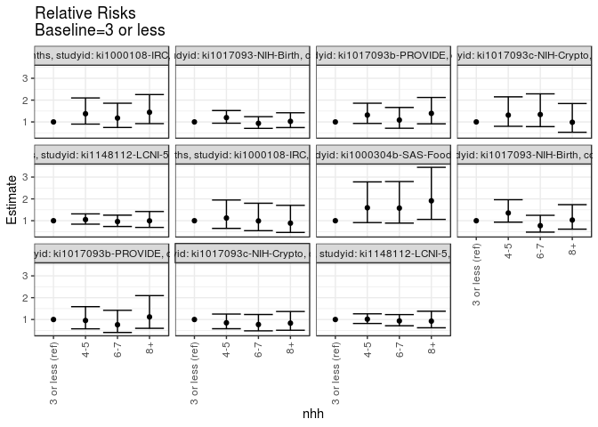

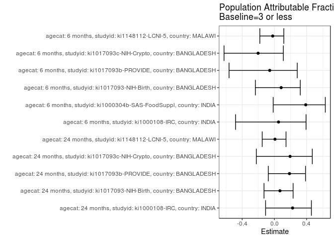

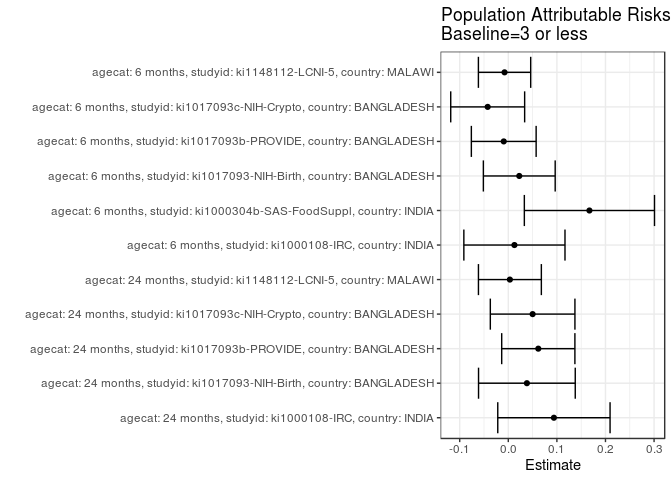

## Results Table

### Parameter: TSM

| agecat | studyid | country | intervention_level | baseline_level | estimate | ci_lower | ci_upper |
| --- | --- | --- | --- | --- | --- | --- | --- |
| 6 months | ki1000108-IRC | INDIA | 3 or less | NA | 0.2330912 | 0.1208589 | 0.3453235 |
| 6 months | ki1000108-IRC | INDIA | 4-5 | NA | 0.2619788 | 0.1923636 | 0.3315941 |
| 6 months | ki1000108-IRC | INDIA | 6-7 | NA | 0.2308250 | 0.1492763 | 0.3123737 |
| 6 months | ki1000108-IRC | INDIA | 8+ | NA | 0.2070143 | 0.1160367 | 0.2979920 |
| 6 months | ki1000304b-SAS-FoodSuppl | INDIA | 3 or less | NA | 0.2619875 | 0.1245629 | 0.3994121 |
| 6 months | ki1000304b-SAS-FoodSuppl | INDIA | 4-5 | NA | 0.4175131 | 0.3399362 | 0.4950899 |
| 6 months | ki1000304b-SAS-FoodSuppl | INDIA | 6-7 | NA | 0.4132611 | 0.3202102 | 0.5063121 |
| 6 months | ki1000304b-SAS-FoodSuppl | INDIA | 8+ | NA | 0.5009882 | 0.3665649 | 0.6354116 |
| 6 months | ki1017093-NIH-Birth | BANGLADESH | 3 or less | NA | 0.2455605 | 0.1656352 | 0.3254858 |
| 6 months | ki1017093-NIH-Birth | BANGLADESH | 4-5 | NA | 0.3325146 | 0.2705994 | 0.3944297 |
| 6 months | ki1017093-NIH-Birth | BANGLADESH | 6-7 | NA | 0.1895847 | 0.1214731 | 0.2576964 |
| 6 months | ki1017093-NIH-Birth | BANGLADESH | 8+ | NA | 0.2532822 | 0.1495550 | 0.3570093 |
| 6 months | ki1017093b-PROVIDE | BANGLADESH | 3 or less | NA | 0.1705975 | 0.0965954 | 0.2445995 |
| 6 months | ki1017093b-PROVIDE | BANGLADESH | 4-5 | NA | 0.1628055 | 0.1187957 | 0.2068153 |
| 6 months | ki1017093b-PROVIDE | BANGLADESH | 6-7 | NA | 0.1296241 | 0.0706292 | 0.1886191 |
| 6 months | ki1017093b-PROVIDE | BANGLADESH | 8+ | NA | 0.1907512 | 0.1033089 | 0.2781935 |
| 6 months | ki1017093c-NIH-Crypto | BANGLADESH | 3 or less | NA | 0.2522059 | 0.1697599 | 0.3346518 |
| 6 months | ki1017093c-NIH-Crypto | BANGLADESH | 4-5 | NA | 0.2141563 | 0.1697485 | 0.2585640 |
| 6 months | ki1017093c-NIH-Crypto | BANGLADESH | 6-7 | NA | 0.1940750 | 0.1289732 | 0.2591768 |
| 6 months | ki1017093c-NIH-Crypto | BANGLADESH | 8+ | NA | 0.2102182 | 0.1321940 | 0.2882423 |
| 6 months | ki1148112-LCNI-5 | MALAWI | 3 or less | NA | 0.3704512 | 0.3082919 | 0.4326105 |
| 6 months | ki1148112-LCNI-5 | MALAWI | 4-5 | NA | 0.3763732 | 0.3241953 | 0.4285510 |
| 6 months | ki1148112-LCNI-5 | MALAWI | 6-7 | NA | 0.3463107 | 0.2723090 | 0.4203125 |
| 6 months | ki1148112-LCNI-5 | MALAWI | 8+ | NA | 0.3426724 | 0.2180900 | 0.4672547 |
| 24 months | ki1000108-IRC | INDIA | 3 or less | NA | 0.3217697 | 0.1981917 | 0.4453477 |
| 24 months | ki1000108-IRC | INDIA | 4-5 | NA | 0.4423091 | 0.3643247 | 0.5202934 |
| 24 months | ki1000108-IRC | INDIA | 6-7 | NA | 0.3786351 | 0.2852980 | 0.4719722 |
| 24 months | ki1000108-IRC | INDIA | 8+ | NA | 0.4641316 | 0.3584445 | 0.5698186 |
| 24 months | ki1017093-NIH-Birth | BANGLADESH | 3 or less | NA | 0.5164958 | 0.4062938 | 0.6266978 |
| 24 months | ki1017093-NIH-Birth | BANGLADESH | 4-5 | NA | 0.6180724 | 0.5477723 | 0.6883726 |
| 24 months | ki1017093-NIH-Birth | BANGLADESH | 6-7 | NA | 0.4829928 | 0.3897819 | 0.5762037 |
| 24 months | ki1017093-NIH-Birth | BANGLADESH | 8+ | NA | 0.5303127 | 0.3996029 | 0.6610225 |
| 24 months | ki1017093b-PROVIDE | BANGLADESH | 3 or less | NA | 0.2675471 | 0.1856661 | 0.3494281 |
| 24 months | ki1017093b-PROVIDE | BANGLADESH | 4-5 | NA | 0.3518422 | 0.2946295 | 0.4090548 |
| 24 months | ki1017093b-PROVIDE | BANGLADESH | 6-7 | NA | 0.2907807 | 0.2041417 | 0.3774197 |
| 24 months | ki1017093b-PROVIDE | BANGLADESH | 8+ | NA | 0.3722046 | 0.2628647 | 0.4815445 |
| 24 months | ki1017093c-NIH-Crypto | BANGLADESH | 3 or less | NA | 0.2067453 | 0.1148441 | 0.2986465 |
| 24 months | ki1017093c-NIH-Crypto | BANGLADESH | 4-5 | NA | 0.2711970 | 0.2132746 | 0.3291195 |
| 24 months | ki1017093c-NIH-Crypto | BANGLADESH | 6-7 | NA | 0.2769871 | 0.1949421 | 0.3590320 |
| 24 months | ki1017093c-NIH-Crypto | BANGLADESH | 8+ | NA | 0.2034909 | 0.1134984 | 0.2934834 |
| 24 months | ki1148112-LCNI-5 | MALAWI | 3 or less | NA | 0.4357216 | 0.3590338 | 0.5124094 |
| 24 months | ki1148112-LCNI-5 | MALAWI | 4-5 | NA | 0.4582217 | 0.3951230 | 0.5213204 |
| 24 months | ki1148112-LCNI-5 | MALAWI | 6-7 | NA | 0.4187402 | 0.3339023 | 0.5035781 |
| 24 months | ki1148112-LCNI-5 | MALAWI | 8+ | NA | 0.4329386 | 0.2968488 | 0.5690283 |

### Parameter: E(Y)

| agecat | studyid | country | intervention_level | baseline_level | estimate | ci_lower | ci_upper |
| --- | --- | --- | --- | --- | --- | --- | --- |
| 6 months | ki1000108-IRC | INDIA | NA | NA | 0.2457002 | 0.2038248 | 0.2875757 |
| 6 months | ki1000304b-SAS-FoodSuppl | INDIA | NA | NA | 0.4289474 | 0.3791199 | 0.4787748 |
| 6 months | ki1017093-NIH-Birth | BANGLADESH | NA | NA | 0.2681564 | 0.2306532 | 0.3056597 |
| 6 months | ki1017093b-PROVIDE | BANGLADESH | NA | NA | 0.1612350 | 0.1313580 | 0.1911120 |
| 6 months | ki1017093c-NIH-Crypto | BANGLADESH | NA | NA | 0.2097902 | 0.1799252 | 0.2396552 |
| 6 months | ki1148112-LCNI-5 | MALAWI | NA | NA | 0.3627451 | 0.3297365 | 0.3957537 |
| 24 months | ki1000108-IRC | INDIA | NA | NA | 0.4156479 | 0.3678270 | 0.4634689 |
| 24 months | ki1017093-NIH-Birth | BANGLADESH | NA | NA | 0.5547786 | 0.5076945 | 0.6018626 |
| 24 months | ki1017093b-PROVIDE | BANGLADESH | NA | NA | 0.3292894 | 0.2909105 | 0.3676684 |
| 24 months | ki1017093c-NIH-Crypto | BANGLADESH | NA | NA | 0.2568093 | 0.2190047 | 0.2946140 |
| 24 months | ki1148112-LCNI-5 | MALAWI | NA | NA | 0.4390244 | 0.3983906 | 0.4796582 |

### Parameter: RR

| agecat | studyid | country | intervention_level | baseline_level | estimate | ci_lower | ci_upper |
| --- | --- | --- | --- | --- | --- | --- | --- |
| 6 months | ki1000108-IRC | INDIA | 3 or less | 3 or less | 1.0000000 | 1.0000000 | 1.000000 |
| 6 months | ki1000108-IRC | INDIA | 4-5 | 3 or less | 1.1239328 | 0.6483798 | 1.948279 |
| 6 months | ki1000108-IRC | INDIA | 6-7 | 3 or less | 0.9902776 | 0.5445988 | 1.800683 |
| 6 months | ki1000108-IRC | INDIA | 8+ | 3 or less | 0.8881258 | 0.4629776 | 1.703684 |
| 6 months | ki1000304b-SAS-FoodSuppl | INDIA | 3 or less | 3 or less | 1.0000000 | 1.0000000 | 1.000000 |
| 6 months | ki1000304b-SAS-FoodSuppl | INDIA | 4-5 | 3 or less | 1.5936373 | 0.9138097 | 2.779222 |
| 6 months | ki1000304b-SAS-FoodSuppl | INDIA | 6-7 | 3 or less | 1.5774077 | 0.8902386 | 2.794998 |
| 6 months | ki1000304b-SAS-FoodSuppl | INDIA | 8+ | 3 or less | 1.9122599 | 1.0609274 | 3.446737 |
| 6 months | ki1017093-NIH-Birth | BANGLADESH | 3 or less | 3 or less | 1.0000000 | 1.0000000 | 1.000000 |
| 6 months | ki1017093-NIH-Birth | BANGLADESH | 4-5 | 3 or less | 1.3541045 | 0.9343222 | 1.962491 |
| 6 months | ki1017093-NIH-Birth | BANGLADESH | 6-7 | 3 or less | 0.7720489 | 0.4777914 | 1.247531 |
| 6 months | ki1017093-NIH-Birth | BANGLADESH | 8+ | 3 or less | 1.0314450 | 0.6130093 | 1.735502 |
| 6 months | ki1017093b-PROVIDE | BANGLADESH | 3 or less | 3 or less | 1.0000000 | 1.0000000 | 1.000000 |
| 6 months | ki1017093b-PROVIDE | BANGLADESH | 4-5 | 3 or less | 0.9543254 | 0.5733548 | 1.588435 |
| 6 months | ki1017093b-PROVIDE | BANGLADESH | 6-7 | 3 or less | 0.7598245 | 0.4060690 | 1.421761 |
| 6 months | ki1017093b-PROVIDE | BANGLADESH | 8+ | 3 or less | 1.1181362 | 0.5966459 | 2.095428 |
| 6 months | ki1017093c-NIH-Crypto | BANGLADESH | 3 or less | 3 or less | 1.0000000 | 1.0000000 | 1.000000 |
| 6 months | ki1017093c-NIH-Crypto | BANGLADESH | 4-5 | 3 or less | 0.8491328 | 0.5770347 | 1.249537 |
| 6 months | ki1017093c-NIH-Crypto | BANGLADESH | 6-7 | 3 or less | 0.7695104 | 0.4814799 | 1.229846 |
| 6 months | ki1017093c-NIH-Crypto | BANGLADESH | 8+ | 3 or less | 0.8335181 | 0.5083604 | 1.366653 |
| 6 months | ki1148112-LCNI-5 | MALAWI | 3 or less | 3 or less | 1.0000000 | 1.0000000 | 1.000000 |
| 6 months | ki1148112-LCNI-5 | MALAWI | 4-5 | 3 or less | 1.0159858 | 0.8186576 | 1.260878 |
| 6 months | ki1148112-LCNI-5 | MALAWI | 6-7 | 3 or less | 0.9348349 | 0.7131982 | 1.225348 |
| 6 months | ki1148112-LCNI-5 | MALAWI | 8+ | 3 or less | 0.9250134 | 0.6205351 | 1.378890 |
| 24 months | ki1000108-IRC | INDIA | 3 or less | 3 or less | 1.0000000 | 1.0000000 | 1.000000 |
| 24 months | ki1000108-IRC | INDIA | 4-5 | 3 or less | 1.3746137 | 0.9005707 | 2.098184 |
| 24 months | ki1000108-IRC | INDIA | 6-7 | 3 or less | 1.1767270 | 0.7454663 | 1.857477 |
| 24 months | ki1000108-IRC | INDIA | 8+ | 3 or less | 1.4424340 | 0.9229917 | 2.254208 |
| 24 months | ki1017093-NIH-Birth | BANGLADESH | 3 or less | 3 or less | 1.0000000 | 1.0000000 | 1.000000 |
| 24 months | ki1017093-NIH-Birth | BANGLADESH | 4-5 | 3 or less | 1.1966650 | 0.9412831 | 1.521335 |
| 24 months | ki1017093-NIH-Birth | BANGLADESH | 6-7 | 3 or less | 0.9351341 | 0.7048531 | 1.240650 |
| 24 months | ki1017093-NIH-Birth | BANGLADESH | 8+ | 3 or less | 1.0267513 | 0.7420930 | 1.420601 |
| 24 months | ki1017093b-PROVIDE | BANGLADESH | 3 or less | 3 or less | 1.0000000 | 1.0000000 | 1.000000 |
| 24 months | ki1017093b-PROVIDE | BANGLADESH | 4-5 | 3 or less | 1.3150663 | 0.9314603 | 1.856654 |
| 24 months | ki1017093b-PROVIDE | BANGLADESH | 6-7 | 3 or less | 1.0868393 | 0.7104376 | 1.662665 |
| 24 months | ki1017093b-PROVIDE | BANGLADESH | 8+ | 3 or less | 1.3911741 | 0.9126181 | 2.120674 |
| 24 months | ki1017093c-NIH-Crypto | BANGLADESH | 3 or less | 3 or less | 1.0000000 | 1.0000000 | 1.000000 |
| 24 months | ki1017093c-NIH-Crypto | BANGLADESH | 4-5 | 3 or less | 1.3117447 | 0.8005473 | 2.149372 |
| 24 months | ki1017093c-NIH-Crypto | BANGLADESH | 6-7 | 3 or less | 1.3397504 | 0.7848047 | 2.287106 |
| 24 months | ki1017093c-NIH-Crypto | BANGLADESH | 8+ | 3 or less | 0.9842590 | 0.5255457 | 1.843352 |
| 24 months | ki1148112-LCNI-5 | MALAWI | 3 or less | 3 or less | 1.0000000 | 1.0000000 | 1.000000 |
| 24 months | ki1148112-LCNI-5 | MALAWI | 4-5 | 3 or less | 1.0516388 | 0.8425216 | 1.312660 |
| 24 months | ki1148112-LCNI-5 | MALAWI | 6-7 | 3 or less | 0.9610269 | 0.7358809 | 1.255057 |
| 24 months | ki1148112-LCNI-5 | MALAWI | 8+ | 3 or less | 0.9936128 | 0.6941412 | 1.422285 |

### Parameter: PAR

| agecat | studyid | country | intervention_level | baseline_level | estimate | ci_lower | ci_upper |
| --- | --- | --- | --- | --- | --- | --- | --- |
| 6 months | ki1000108-IRC | INDIA | 3 or less | NA | 0.0126090 | -0.0914589 | 0.1166770 |
| 6 months | ki1000304b-SAS-FoodSuppl | INDIA | 3 or less | NA | 0.1669598 | 0.0330241 | 0.3008956 |
| 6 months | ki1017093-NIH-Birth | BANGLADESH | 3 or less | NA | 0.0225959 | -0.0513071 | 0.0964990 |
| 6 months | ki1017093b-PROVIDE | BANGLADESH | 3 or less | NA | -0.0093625 | -0.0760227 | 0.0572977 |
| 6 months | ki1017093c-NIH-Crypto | BANGLADESH | 3 or less | NA | -0.0424157 | -0.1184781 | 0.0336468 |
| 6 months | ki1148112-LCNI-5 | MALAWI | 3 or less | NA | -0.0077061 | -0.0615124 | 0.0461002 |
| 24 months | ki1000108-IRC | INDIA | 3 or less | NA | 0.0938782 | -0.0216774 | 0.2094339 |
| 24 months | ki1017093-NIH-Birth | BANGLADESH | 3 or less | NA | 0.0382828 | -0.0612332 | 0.1377988 |
| 24 months | ki1017093b-PROVIDE | BANGLADESH | 3 or less | NA | 0.0617423 | -0.0135740 | 0.1370587 |
| 24 months | ki1017093c-NIH-Crypto | BANGLADESH | 3 or less | NA | 0.0500641 | -0.0370004 | 0.1371285 |
| 24 months | ki1148112-LCNI-5 | MALAWI | 3 or less | NA | 0.0033028 | -0.0614292 | 0.0680348 |

### Parameter: PAF

| agecat | studyid | country | intervention_level | baseline_level | estimate | ci_lower | ci_upper |
| --- | --- | --- | --- | --- | --- | --- | --- |
| 6 months | ki1000108-IRC | INDIA | 3 or less | NA | 0.0513188 | -0.4827445 | 0.3930202 |
| 6 months | ki1000304b-SAS-FoodSuppl | INDIA | 3 or less | NA | 0.3892316 | -0.0151362 | 0.6325241 |
| 6 months | ki1017093-NIH-Birth | BANGLADESH | 3 or less | NA | 0.0842640 | -0.2362576 | 0.3216847 |
| 6 months | ki1017093b-PROVIDE | BANGLADESH | 3 or less | NA | -0.0580672 | -0.5635580 | 0.2840008 |
| 6 months | ki1017093c-NIH-Crypto | BANGLADESH | 3 or less | NA | -0.2021813 | -0.6258724 | 0.1110989 |
| 6 months | ki1148112-LCNI-5 | MALAWI | 3 or less | NA | -0.0212439 | -0.1809786 | 0.1168857 |
| 24 months | ki1000108-IRC | INDIA | 3 or less | NA | 0.2258600 | -0.1091260 | 0.4596711 |
| 24 months | ki1017093-NIH-Birth | BANGLADESH | 3 or less | NA | 0.0690055 | -0.1289548 | 0.2322538 |
| 24 months | ki1017093b-PROVIDE | BANGLADESH | 3 or less | NA | 0.1875017 | -0.0758355 | 0.3863807 |
| 24 months | ki1017093c-NIH-Crypto | BANGLADESH | 3 or less | NA | 0.1949464 | -0.2247379 | 0.4708164 |
| 24 months | ki1148112-LCNI-5 | MALAWI | 3 or less | NA | 0.0075230 | -0.1514456 | 0.1445445 |